# Cooperation between arbuscular mycorrhizal fungi and plant growth-promoting bacteria and their effects on plant growth and soil quality

2025-01-08

[Cooperation between arbuscular mycorrhizal fungi and plant growth-promoting bacteria and their effects on plant growth and soil quality](https://peerj.com/articles/13080/)

## Preamble :

This is the final project for the subject “Data Acquisition Analysis and Scientific Methods for Life Sciences” shorted as “Data” from the first course of the Master Plant Health at the Universitat Politècnica de València.

## Guidelines :

In this project the students chose a scientific article and redo all possible statistic analyses and graphics from it, trying different approaches to see if they can improve them. They will use the data included in the article and follow the Material and methods chapter as a guide.

### Introduction. Why your project is interesting? & What is known already about it?

We chose this scientific paper because we were interested in the knowledge we could gain about the relationship between plants & microorganisms *(here arbuscular mycorrhizal fungi (AMF) & plant growth-promoting bacteria (PGPB))*. A way to understand how the growth of plants & physico chemical properties of the soil are influenced by different treatments. Finaly, as “Almost 25% of the Earth’s biodiversity is composed of soil microorganisms (…)” (Fierer, 2017; Wagg et al., 2019; Whitman, Coleman & Wiebe, 1998), we thought we would acquire knowledge that we can later on, apply during our career.

### What we know already

**AMF** - present to 70% of the terrestrial plants *“Arbuscular mycorrhizal fungi (AMF), (…) maintain symbiotic relationships with over 70% of terrestrial plants and provide nutrients and water to plants in exchange for sugars through their arbuscules (…)”* (Schussler, Schwarzott & Walker, 2001; Wagg et al., 2019) and favorise the exchange of nutrients/sugars thanks to arbuscules. It enhances resilience of plants for drought, heavy metals & pathogens.

**PGPR** - include B (Bacillus spp…), contribute to the fixation of N, solubilisation of P, production of phytohormones & systemic resistance. *Bacillus spp. promotes plant growth by fixing N, solubilizing and mineralizing P and other nutrients, stimulating phytohormones, producing siderophores, inducing systemic resistance (ISR), and enhancing their tolerance to abiotic stresses* (Bonfante & Genre, 2010; Saxena et al., 2020). AMF & PGPR provide ecological solutions to improve health soil & plants productivity.

### Objectives and hypotheses

The objectives are to analyse if arbuscular mycorrhizal fungi* AMF* & plant growth-promoting rhizobacteria *PGRB* have any synergy effects on nutrients uptakes or plant growth to a more effective extent than for each microorganism studied alone.

The hypotheses are 1) AMF and PGPR could mutually symbiose and enhance the plant growth of Elymus nutans Griseb, & (2) the co-existence of AMF and PGPR could improve plant traits and soil quality better than their individual applications.

### Origin & structure of the data

It comes from the scientific article [Cooperation between arbuscular mycorrhizal fungi and plant growth-promoting bacteria and their effects on plant growth and soil quality](https://peerj.com/articles/13080/) by Yu L, Zhang H, Zhang W, Liu K, Liu M, Shao X. 2022.

```r
library(knitr)
kable(plant_soil, caption = "<span style='color: red; text-decoration: underline; font-style: italic; font-size: 20px;'>plant_soil</span>")
```

plant_soil

| Group | Aboveground_Biomass | Belowground_Biomass | Total_Biomass | RootLength | RootSurfaceArea | RootAverageDiameter | Rvolume | Rootbranches | SIZE | R/S_ratio | HEIGHT | NH4+-N | NO3-N | Total_N | Total_C | Available_P | Total_P | ALP | UE | EC | PH | Plant_P | Plant_N | Plant_C | SRL |
| --- | --- | --- | --- | --- | --- | --- | --- | --- | --- | --- | --- | --- | --- | --- | --- | --- | --- | --- | --- | --- | --- | --- | --- | --- | --- |
| CK1 | 1.06 | 0.41 | 1.47 | 275.16 | 749.58 | 9.06 | 166.63 | 1646.67 | 0.41 | 0.39 | 23.58 | 5.58 | 161.20 | 0.22 | 3.54 | 2.43 | 0.14 | 1948.56 | 108.97 | 461 | 7.50 | 0.0688263 | 2.28 | 42.48 | 6.711220 |
| CK1 | 1.28 | 0.49 | 1.77 | 270.68 | 756.69 | 9.81 | 177.53 | 1062.00 | 0.65 | 0.38 | 26.08 | 9.83 | 142.40 | 0.20 | 3.41 | 2.16 | 0.45 | 2016.59 | 120.66 | 325 | 8.37 | 0.0693685 | 1.91 | 42.39 | 5.524082 |
| CK1 | 1.94 | 0.55 | 2.49 | 334.46 | 852.31 | 8.15 | 174.32 | 1201.67 | 0.62 | 0.29 | 30.23 | 6.87 | 86.61 | 0.19 | 3.22 | 2.15 | 0.53 | 2424.77 | 114.56 | 336 | 8.37 | 0.0730622 | 2.04 | 42.30 | 6.081091 |
| CK1 | 1.80 | 0.74 | 2.54 | 363.16 | 824.37 | 7.76 | 157.95 | 1506.33 | 0.63 | 0.41 | 27.50 | 6.97 | 107.99 | 0.22 | 3.51 | 2.56 | 0.54 | 2065.18 | 455.75 | 326 | 8.29 | 0.0181898 | 2.27 | 42.90 | 4.907568 |
| CK1 | 2.07 | 0.47 | 2.54 | 424.98 | 879.61 | 6.63 | 145.54 | 1632.33 | 0.47 | 0.23 | 31.52 | 7.67 | 161.40 | 0.26 | 3.40 | 2.17 | 0.50 | 2599.70 | 108.97 | 299 | 8.26 | 0.0758007 | 2.14 | 42.60 | 9.042128 |
| CK1 | 1.71 | 0.71 | 2.42 | 242.92 | 655.50 | 9.03 | 145.08 | 829.67 | 0.66 | 0.41 | 27.43 | 5.64 | 73.17 | 0.21 | 3.54 | 2.09 | 0.45 | 1851.37 | 132.86 | 247 | 8.44 | 0.0635255 | 1.94 | 43.17 | 3.421409 |
| A2 | 3.00 | 1.45 | 4.45 | 682.25 | 924.27 | 4.19 | 96.97 | 5640.67 | 0.82 | 0.48 | 37.10 | 8.35 | 182.70 | 0.26 | 3.49 | 2.23 | 0.34 | 3017.59 | 468.97 | 305 | 8.22 | 0.0175278 | 2.01 | 42.94 | 4.705172 |
| A2 | 3.00 | 1.50 | 4.50 | 682.09 | 842.44 | 4.10 | 87.15 | 6155.00 | 0.81 | 0.50 | 28.83 | 8.01 | 107.53 | 0.22 | 3.57 | 2.39 | 0.49 | 3007.88 | 392.69 | 267 | 8.42 | 0.0214418 | 1.85 | 43.41 | 4.547267 |
| A2 | 2.65 | 1.28 | 3.93 | 652.48 | 934.03 | 4.65 | 108.56 | 3510.67 | 0.80 | 0.48 | 33.17 | 8.42 | 83.75 | 0.21 | 3.40 | 2.05 | 0.46 | 2949.56 | 352.02 | 297 | 8.35 | 0.0237202 | 2.05 | 42.76 | 5.097500 |
| A2 | 2.71 | 1.08 | 3.79 | 573.57 | 922.97 | 5.55 | 128.53 | 2891.00 | 1.08 | 0.40 | 34.92 | 8.56 | 41.67 | 0.22 | 3.42 | 2.31 | 0.49 | 2142.93 | 360.15 | 236 | 8.43 | 0.0234069 | 1.98 | 43.03 | 5.310833 |
| A2 | 3.11 | 1.26 | 4.37 | 483.93 | 769.87 | 5.05 | 97.79 | 2097.67 | 0.87 | 0.40 | 35.17 | 7.76 | 107.37 | 0.23 | 3.38 | 2.21 | 0.53 | 2036.03 | 340.32 | 260 | 8.37 | 0.0245945 | 1.74 | 42.29 | 3.840714 |
| A2 | 2.38 | 1.09 | 3.47 | 590.92 | 908.33 | 4.93 | 112.62 | 4669.67 | 0.73 | 0.46 | 35.13 | 6.94 | 60.36 | 0.22 | 3.45 | 2.07 | 0.49 | 2570.54 | 442.02 | 248 | 8.49 | 0.0192073 | 2.22 | 43.33 | 5.421284 |
| B3 | 1.68 | 0.78 | 2.46 | 531.38 | 900.35 | 5.51 | 124.17 | 2033.00 | 0.66 | 0.46 | 30.50 | 10.77 | 71.90 | 0.20 | 3.57 | 1.97 | 0.50 | 2580.26 | 191.85 | 238 | 8.49 | 0.0442533 | 1.84 | 43.08 | 6.812564 |
| B3 | 1.78 | 0.98 | 2.76 | 568.62 | 908.13 | 5.10 | 116.96 | 3800.00 | 0.61 | 0.55 | 30.38 | 8.34 | 65.29 | 0.19 | 3.46 | 2.07 | 0.53 | 2191.52 | 314.39 | 254 | 8.47 | 0.0269411 | 1.84 | 43.13 | 5.802245 |
| B3 | 1.63 | 0.68 | 2.31 | 329.58 | 864.79 | 8.37 | 180.70 | 1205.33 | 0.76 | 0.41 | 27.43 | 8.00 | 79.29 | 0.19 | 3.39 | 2.17 | 0.48 | 1870.81 | 192.36 | 298 | 8.44 | 0.0438761 | 1.90 | 42.49 | 4.846765 |
| B3 | 1.66 | 0.65 | 2.31 | 331.15 | 788.11 | 7.79 | 154.79 | 2615.00 | 0.75 | 0.39 | 28.83 | 6.56 | 69.75 | 0.20 | 3.40 | 2.29 | 0.49 | 1997.15 | 126.25 | 257 | 8.47 | 0.0670891 | 2.17 | 42.16 | 5.094615 |
| B3 | 1.58 | 0.61 | 2.19 | 480.38 | 812.36 | 5.46 | 110.14 | 2111.00 | 0.62 | 0.39 | 26.50 | 7.38 | 92.70 | 0.20 | 3.42 | 2.15 | 0.40 | 2278.99 | 140.49 | 284 | 8.37 | 0.0595772 | 2.20 | 42.46 | 7.875082 |
| B3 | 1.69 | 0.78 | 2.47 | 439.80 | 1008.46 | 7.58 | 191.56 | 1828.00 | 0.76 | 0.46 | 30.83 | 6.74 | 110.28 | 0.21 | 3.39 | 2.11 | 0.50 | 2473.36 | 201.51 | 262 | 8.36 | 0.0414868 | 1.88 | 42.57 | 5.638462 |
| AB5 | 3.04 | 1.80 | 4.84 | 548.17 | 876.15 | 5.11 | 111.75 | 2795.67 | 0.84 | 0.59 | 39.58 | 8.36 | 48.84 | 0.21 | 3.50 | 2.39 | 0.46 | 3124.50 | 310.47 | 209 | 8.44 | 0.0271846 | 1.90 | 43.20 | 3.045389 |
| AB5 | 3.68 | 1.06 | 4.74 | 719.72 | 862.62 | 3.83 | 82.78 | 3750.33 | 0.91 | 0.29 | 39.50 | 8.24 | 34.00 | 0.22 | 3.50 | 2.43 | 0.49 | 3075.90 | 280.98 | 169 | 8.48 | 0.0301801 | 1.78 | 41.64 | 6.789811 |
| AB5 | 3.00 | 1.48 | 4.48 | 671.82 | 930.42 | 4.42 | 102.90 | 3251.00 | 0.91 | 0.49 | 34.30 | 7.80 | 59.25 | 0.21 | 3.47 | 2.19 | 0.47 | 2794.07 | 292.17 | 224 | 8.45 | 0.0289215 | 2.28 | 43.16 | 4.539324 |
| AB5 | 2.59 | 1.59 | 4.18 | 759.05 | 784.84 | 3.50 | 68.63 | 3742.33 | 0.83 | 0.61 | 32.42 | 10.74 | 58.11 | 0.20 | 3.51 | 5.83 | 0.47 | 3105.06 | 299.29 | 205 | 8.48 | 0.0283337 | 1.89 | 43.02 | 4.773899 |
| AB5 | 3.45 | 1.68 | 5.13 | 892.00 | 886.52 | 3.30 | 73.72 | 4783.33 | 0.87 | 0.49 | 40.42 | 8.96 | 33.30 | 0.22 | 3.38 | 2.15 | 0.48 | 2726.04 | 294.20 | 211 | 8.43 | 0.0286540 | 1.87 | 42.08 | 5.309524 |
| AB5 | 3.19 | 1.90 | 5.09 | 685.45 | 818.73 | 3.81 | 78.14 | 3451.33 | 0.79 | 0.60 | 36.92 | 11.32 | 42.53 | 0.22 | 3.45 | 2.15 | 0.45 | 2570.54 | 223.02 | 240 | 8.43 | 0.0377993 | 1.62 | 42.71 | 3.607632 |

*Details - CK1 : Control, A2 : Inocculation with AMF only, B3 : Incculation with Bacillus only, AB5 : Incculation with Bacillus & AMF*

### Analyitical Methods used

Correlation analyses, ANOVA analyse, and some multivariate analyses were realized :

- ANOVA (Analysis of Variance)

ANOVA (Analysis of Variance) is used to compare the means of multiple variances to determine if there are statistically significant differences between them. Here to compare the effects of AMF or PGPB treatment only, or combination of both treatments or none of them on soil content and plant growth. Also a way to analyze the impact of independent variables on a dependent variable & to test interactions between factors. Finaly done in order to reliably and efficiently compare the means of multiple groups while controlling for statistical errors.

- PCA (Principal Component Analysis)

PCA is a statistical technique used for dimensional reduction and data simplification. Transforming high-dimensional data into a smaller number of uncorrelated variables called *principal components*. These components capture the most important features of the original data.

**NB**: By keeping only the most important components, PCA simplifies the data without losing much information, which is particularly useful for tasks like pattern recognition, data visualization, and improving the performance of machine learning models.

- LDA (Linear Discriminant Analysis) It works by finding a linear combination of features that best separates multiple classes.

**NB**: Unlike PCA (*unsupervising and focusing on maximizing variance*) LDA aims to maximize the separation between different classes.

We plan to start with each variable analyses separately then ANOVA analyses we’ll combine these small results analyses with the knowledge acquire from the article chosen to define the larger scale multivariate analyses. These might be a relationship between soil nutrients/quality and plant size measurements (multiple roots measurements and above ground biomass).

# P values for each variable obtained by ANOVA analyisis, as well as Bonferroni corrected P values

```r
library(DT)

# Filter numeric variables for ANOVA
response_vars <- colnames(plant_soil)[sapply(plant_soil, is.numeric) & colnames(plant_soil) != "Group"]
# Initialize a dataframe to store ANOVA results
anova_results <- data.frame(Variable = character(), P_Value = numeric(), stringsAsFactors = FALSE)

# Perform ANOVA for each numeric variable
for (var in response_vars) {
  formula <- as.formula(paste("`", var, "` ~ Group", sep = ""))
  anova_result <- aov(formula, data = plant_soil)
  anova_summary <- summary(anova_result)

  # Extract p-value
  p_value <- anova_summary[[1]]$`Pr(>F)`[1]
  anova_results <- rbind(anova_results, data.frame(Variable = var, P_Value = p_value))
}

# Apply Bonferroni correction
anova_results$Bonferroni_P <- p.adjust(anova_results$P_Value, method = "bonferroni")

# Save ANOVA results to a CSV file
write.csv(anova_results, "ANOVA_Results.csv", row.names = FALSE)

library(knitr)

# Display the results as a simple table
kable(anova_results, caption = "ANOVA Results with Bonferroni Correction")
```

ANOVA Results with Bonferroni Correction

| Variable | P_Value | Bonferroni_P |
| --- | --- | --- |
| Aboveground_Biomass | 0.0000000 | 0.0000004 |
| Belowground_Biomass | 0.0000000 | 0.0000011 |
| Total_Biomass | 0.0000000 | 0.0000000 |
| RootLength | 0.0000016 | 0.0000404 |
| RootSurfaceArea | 0.0893373 | 1.0000000 |
| RootAverageDiameter | 0.0000010 | 0.0000261 |
| Rvolume | 0.0000199 | 0.0004968 |
| Rootbranches | 0.0002484 | 0.0062101 |
| SIZE | 0.0000457 | 0.0011429 |
| R/S_ratio | 0.0210051 | 0.5251273 |
| HEIGHT | 0.0000195 | 0.0004874 |
| NH4+-N | 0.0838133 | 1.0000000 |
| NO3-N | 0.0056811 | 0.1420276 |
| Total_N | 0.0433469 | 1.0000000 |
| Total_C | 0.9020266 | 1.0000000 |
| Available_P | 0.3310077 | 1.0000000 |
| Total_P | 0.7903956 | 1.0000000 |
| ALP | 0.0019858 | 0.0496451 |
| UE | 0.0006525 | 0.0163126 |
| EC | 0.0006019 | 0.0150470 |
| PH | 0.1147915 | 1.0000000 |
| Plant_P | 0.0001818 | 0.0045449 |
| Plant_N | 0.2855678 | 1.0000000 |
| Plant_C | 0.5435702 | 1.0000000 |
| SRL | 0.1875362 | 1.0000000 |

# Showcasing all significant ANOVA analyses in boxplots

Here we compiled all boxplots based on our anova analysis. CK1 = Control, A2 = AMF treatment B3 = PGPB, and AB5 = Both PGPB and AMF treatments together.

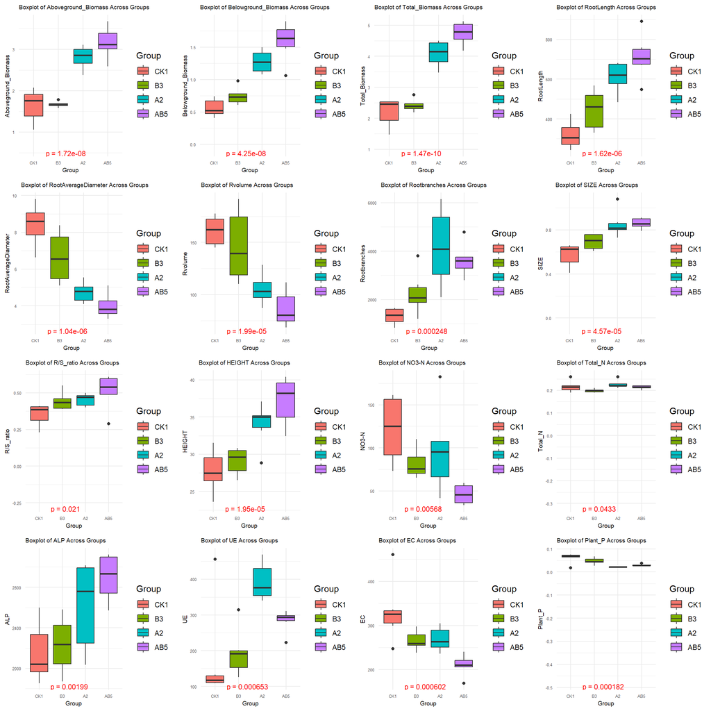

```r
# Load necessary libraries
library(ggplot2)
library(dplyr)
library(gridExtra)

# Assume `plant_soil` is your dataframe
# Rename the grouping column for convenience (if not already done)
colnames(plant_soil)[1] <- "Group"

# Reorder the factor levels of the "Group" column
desired_order <- c("CK1", "B3", "A2", "AB5")
plant_soil$Group <- factor(plant_soil$Group, levels = desired_order)

# Get the names of all response variables (excluding the grouping column)
response_vars <- colnames(plant_soil)[2:ncol(plant_soil)]  # Adjust as needed

# Initialize an empty list to store plots
plot_list <- list()

# Iterate over each response variable to perform ANOVA and plot
for (var in response_vars) {
  # Perform ANOVA
  formula <- as.formula(paste("`", var, "` ~ Group", sep = ""))
  anova_result <- aov(formula, data = plant_soil)
  anova_summary <- summary(anova_result)

  # Extract p-value
  p_value <- anova_summary[[1]]$`Pr(>F)`[1]

  # Only generate plots for significant results
  if (p_value < 0.05) {
    # Visualization using ggplot2
    p <- ggplot(plant_soil, aes_string(x = "Group", y = paste0("`", var, "`"), fill = "Group")) +
      geom_boxplot() +
      theme_minimal() +
      labs(title = paste("Boxplot of", var, "Across Groups"),
           x = "Group",
           y = var) +
      # Dynamically set the y-position for the p-value annotation
      annotate("text", x = 1.5, y = min(plant_soil[[var]], na.rm = TRUE) - 0.5,
               label = paste("p =", signif(p_value, digits = 3)),
               hjust = 0, vjust = 1, size = 3, color = "red") +  # Moved p-value lower
      theme(plot.title = element_text(size = 7),  # Smaller title size
            axis.title = element_text(size = 7),   # Axis title size (optional)
            axis.text = element_text(size = 5))    # Axis labels size (optional)

    # Append the plot to the plot list
    plot_list <- c(plot_list, list(p))
  }
}

# Combine all the plots into a grid
if (length(plot_list) > 0) {
  do.call(grid.arrange, c(plot_list, ncol = 4))  # Adjust ncol for layout
}
```

# Showcasing all ANOVA analysis with significant difference between AMF treatment and AMF + PGPB treatments

To further analyse weather the PGPB had any synergistic effects with AMF we created ANOVA analysis box plots that showcase only AMF and PGPB + AMF treatments only if there is a significant difference between the two treatments not considering other treatments.

We can see that there is a synergistic effect because the treatment AMF + PGPB resulted in a significantly larger biomass, it also resulted in a significantly larger plant phosphorus content. Which is even more interesting since this means that the PGPB increased the Phosphorus uptake of AMF since normally AMF is attributed with the capability of up taking the non mobile nutrient.

We can also see that there is some significant difference between treatments in the soil parameters which is interesting since it might let us understand that with the PGPB present AMF have a different chemical metabolism an secrete different metabolites into the soil. Which shows that there is a clear interaction between PGPB and AMF.

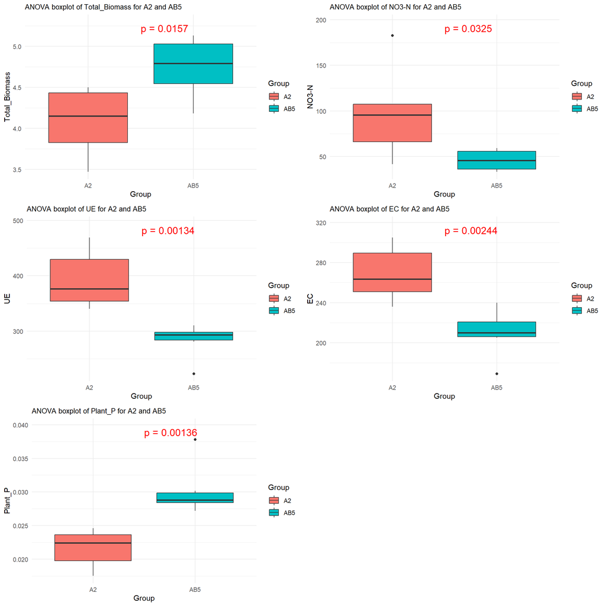

```r
library(gridExtra)

# List to store plots
plots <- list()

# Filter the dataframe
filtered_data <- plant_soil %>% filter(Group %in% c("A2", "AB5"))


# Iterate over response variables
for (var in response_vars) {
  # Perform ANOVA
  formula <- as.formula(paste("`", var, "` ~ Group", sep = ""))
  anova_result <- aov(formula, data = filtered_data)
  anova_summary <- summary(anova_result)

  # Extract p-value
  p_value <- anova_summary[[1]]$`Pr(>F)`[1]

  # Check if p-value is less than 0.05
  if (p_value < 0.05) {
    # Calculate dynamic y-axis limits
    y_min <- min(filtered_data[[var]], na.rm = TRUE)
    y_max <- max(filtered_data[[var]], na.rm = TRUE)
    y_buffer <- (y_max - y_min) * 0.1  # Add 10% buffer for annotation space
    adjusted_y_max <- y_max + y_buffer

    # Create the boxplot
   p <- ggplot(filtered_data, aes_string(x = "Group", y = paste0("`", var, "`"), fill = "Group")) +
      geom_boxplot() +
      theme_minimal() +
      labs(title = paste("ANOVA boxplot of", var, "for A2 and AB5"),
           x = "Group",
           y = var) +
      coord_cartesian(ylim = c(y_min, adjusted_y_max)) +
            annotate("text",
               x = 1.5,
               y = adjusted_y_max - (y_buffer ),  # Moves the text lower
               label = paste("p =", signif(p_value, digits = 3)),
               hjust = 0,
               vjust = -0.5,
               size = 5,
               color = "red")+

      theme(plot.title = element_text(size = 10))

    # Save plot to list
    plots[[length(plots) + 1]] <- p
  }
}

# Arrange plots in a 2-column layout
do.call(grid.arrange, c(plots, ncol = 2))
```

*Details - NO3-N : Nitrate , UE : Soil urease enzyme , EC : Electrical conductivity , Plant P : Plant phosphorus*

# Principle Component Analysis (PCA) of plants measured variables and soil measured variables separately

For the principle components analyisis we decide to separate the measured variables, as there was too many to result in a PCA that is informative at all. So we decide to separate the variables into two groups one group being the Plant Parameters which contained: Aboveground_Biomass, Belowground_Biomass, Total_Biomass, RootLength, RootSurfaceArea, RootAverageDiameter, Rvolume, Rootbranches, SIZE, R/S_ratio, HEIGHT, Plant_P, Plant_N, Plant_C, Specific Root Length.

And soil parameters containing: NH4+-N, NO3-N, Total_N, Total_C, Available_P, Total_P, ALP, UE, EC, PH.

We then conducted a principle components analysis on both groups of variables separately.

For the soil parameters PC1 only explains 42.9% of variance however PC2 explains 27.1% of variance so together explaining 70% of variance. The most important components of PC1 and PC2 of the soil parameters were Soil Urease concentration, soil NO3-N, and EC. All of these point the fact that the metabolism of the plants with and without AMF and PGPB wildly differed. This means that there are not very large variation between Soil paramter variables.

However we could differentiate between treatment groups much better based on plant parameters compared to soil parameters, this is probably because only a few soil parameters had a large variation. Whereas there was a big variation in multiple plant parameters making it easier to differentiate between treatment groups.

[figure not shown]

```r
# 08_PCAsubsetted.R
# Load necessary libraries
if (!require(ggplot2)) install.packages("ggplot2")
if (!require(factoextra)) install.packages("factoextra")

library(ggplot2)
library(factoextra)

# Normalize function: divide each column by its standard deviation
normalize <- function(df) {
  numeric_cols <- sapply(df, is.numeric)  # Identify numeric columns
  df[, numeric_cols] <- scale(df[, numeric_cols], center = FALSE, scale = TRUE)  # Divide by SD
  return(df)
}

# Normalize subsets (excluding 'Group' column)
Plant_param_normalized <- normalize(Plant_param[ , -1])  # Exclude 'Group' for normalization
Soil_param_normalized <- normalize(Soil_param[ , -1])    # Exclude 'Group' for normalization

# Add the 'Group' column back
Plant_param_normalized$Group <- Plant_param$Group
Soil_param_normalized$Group <- Soil_param$Group

# Perform PCA for Plant_param
pca_plant <- prcomp(Plant_param_normalized[ , -ncol(Plant_param_normalized)], center = TRUE, scale. = FALSE)

# Perform PCA for Soil_param
pca_soil <- prcomp(Soil_param_normalized[ , -ncol(Soil_param_normalized)], center = TRUE, scale. = FALSE)

# Scree plot for Plant_param
scree_plant <- fviz_eig(pca_plant, addlabels = TRUE,
                        main = "Scree Plot for Plant Parameters",
                        xlab = "Principal Components",
                        ylab = "Variance Explained (%)")


# Scree plot for Soil_param
scree_soil <- fviz_eig(pca_soil, addlabels = TRUE,
                       main = "Scree Plot for Soil Parameters",
                       xlab = "Principal Components",
                       ylab = "Variance Explained (%)")






pca_plantdf <- as.data.frame(pca_plant$x)  # Extract PCA scores
pca_plantdf$Group <- plant_soil$Group

# Calculate variance explained by PC1 and PC2
explained_variance <- summary(pca_plant)$importance[2, 1:2] * 100  # Extract variance percentages
pc1_label <- paste0("Principal Component 1 (", round(explained_variance[1], 2), "%)")
pc2_label <- paste0("Principal Component 2 (", round(explained_variance[2], 2), "%)")

# PCA Plot with Smaller Ellipses
pca_plant_scatter <- ggplot(pca_plantdf, aes(x = PC1, y = PC2, color = Group)) +
  geom_point(size = 3, alpha = 0.8) +  # Scatter points
  geom_hline(yintercept = 0, linetype = "dashed", color = "gray") +  # Horizontal line at 0
  geom_vline(xintercept = 0, linetype = "dashed", color = "gray") +  # Vertical line at 0
  stat_ellipse(type = "norm", geom = "polygon", alpha = 0.2, aes(fill = Group),
               level = 0.8, show.legend = FALSE) +  # Adjusted ellipses with smaller confidence level
  labs(title = "PCA of Plant Parameters with Treatment Groups",
       x = pc1_label,
       y = pc2_label) +
  theme_minimal() +
  theme(legend.position = "right")


# Calculate percentage contribution for PC1 and PC2
explained_variance <- summary(pca_plant)$importance[2, ] * 100
pc1_label <- paste0("Principal Component 1 (", round(explained_variance[1], 2), "%)")
pc2_label <- paste0("Principal Component 2 (", round(explained_variance[2], 2), "%)")

# Prepare PCA DataFrame for plant_soil
pca_soildf <- as.data.frame(pca_soil$x)  # Extract PCA scores
pca_soildf$Group <- plant_soil$Group

# PCA Plot with Smaller Ellipses for plant_soil
pca_soil_scatter <- ggplot(pca_soildf, aes(x = PC1, y = PC2, color = Group)) +
  geom_point(size = 3, alpha = 0.8) +  # Scatter points
  geom_hline(yintercept = 0, linetype = "dashed", color = "gray") +  # Horizontal line at 0
  geom_vline(xintercept = 0, linetype = "dashed", color = "gray") +  # Vertical line at 0
  stat_ellipse(type = "norm", geom = "polygon", alpha = 0.2, aes(fill = Group),
               level = 0.8, show.legend = FALSE) +  # Adjusted ellipses with smaller confidence level
  labs(title = "PCA of Soil Parameters with Treatment Groups",
       x = pc1_label,
       y = pc2_label) +
  theme_minimal() +
  theme(legend.position = "right")



# Loadings for PCA of Plant_param
loadings_plant <- as.data.frame(pca_plant$rotation)

# Calculate percentage contribution for PC1 and PC2
explained_variance_plant <- summary(pca_plant)$importance[2, ] * 100
pc1_label_plant <- paste0("Principal Component 1 (", round(explained_variance_plant[1], 2), "%)")
pc2_label_plant <- paste0("Principal Component 2 (", round(explained_variance_plant[2], 2), "%)")

# Create a dataframe for arrows
arrows_plant <- data.frame(
  x = 0,  # Origin x
  y = 0,  # Origin y
  xend = loadings_plant[, 1],  # PC1 Loadings
  yend = loadings_plant[, 2],  # PC2 Loadings
  Variables = rownames(loadings_plant)  # Variable names
)

# PCA plot with arrows for Plant_param
pca_plant_arrows <- ggplot() +
  geom_segment(data = arrows_plant, aes(x = x, y = y, xend = xend, yend = yend),
               arrow = arrow(length = unit(0.2, "cm")), color = "blue") +
  geom_text(data = arrows_plant, aes(x = xend, y = yend, label = Variables),
            hjust = 1.1, vjust = 1.1, size = 4, color = "red") +
  geom_hline(yintercept = 0, linetype = "dashed", color = "gray") +  # Horizontal line at 0
  geom_vline(xintercept = 0, linetype = "dashed", color = "gray") +  # Vertical line at 0
  labs(title = "PCA Plot of Plant Parameters (Loadings Only)",
       x = pc1_label_plant,
       y = pc2_label_plant) +
  theme_minimal()



# Loadings for PCA of Soil_param
loadings_soil <- as.data.frame(pca_soil$rotation)

# Calculate percentage contribution for PC1 and PC2
explained_variance_soil <- summary(pca_soil)$importance[2, ] * 100
pc1_label_soil <- paste0("Principal Component 1 (", round(explained_variance_soil[1], 2), "%)")
pc2_label_soil <- paste0("Principal Component 2 (", round(explained_variance_soil[2], 2), "%)")

# Create a dataframe for arrows
arrows_soil <- data.frame(
  x = 0,  # Origin x
  y = 0,  # Origin y
  xend = loadings_soil[, 1],  # PC1 Loadings
  yend = loadings_soil[, 2],  # PC2 Loadings
  Variables = rownames(loadings_soil)  # Variable names
)

# PCA plot with arrows for Soil_param
pca_soil_arrows <- ggplot() +
  geom_segment(data = arrows_soil, aes(x = x, y = y, xend = xend, yend = yend),
               arrow = arrow(length = unit(0.2, "cm")), color = "blue") +
  geom_text(data = arrows_soil, aes(x = xend, y = yend, label = Variables),
            hjust = 1.1, vjust = 1.1, size = 4, color = "red") +
  geom_hline(yintercept = 0, linetype = "dashed", color = "gray") +  # Horizontal line at 0
  geom_vline(xintercept = 0, linetype = "dashed", color = "gray") +  # Vertical line at 0
  labs(title = "PCA Plot of Soil Parameters (Loadings Only)",
       x = pc1_label_soil,
       y = pc2_label_soil) +
  theme_minimal()

library(gridExtra)

grid.arrange(
  scree_plant,
  scree_soil,
  pca_plant_scatter,
  pca_soil_scatter,
  pca_plant_arrows,
  pca_soil_arrows,
  ncol = 2  # 3 columns, 2 rows
)
```

# Comparing PC1 of the Plant parameter analysis to PC1 of the Soil Parameter Analyisis

We then decided to compare PC1 of the Plant parameters and PC1 of the Soil parameters on a scatter plot. Here we can clearly see that the treatment groups are much more clearly separated based on PC1 of plant parameters than based on PC1 of soil parameters. This is probably due because PC1 of Plant parameters much more clearly groups the treatments just on its own it accounts for 73.2% of variance, while PC1 of the Soil Parameters only explains 42.9%. So we can see that the treatments have a much more noticable impact on plant parameters.

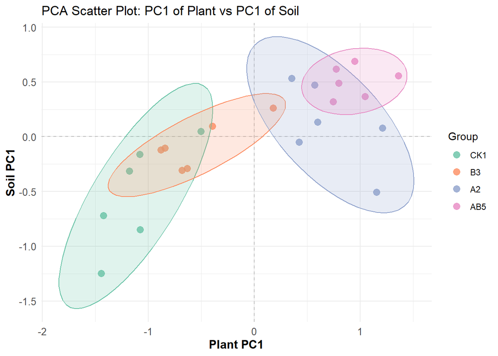

```r
# Combine PCA data for plotting
pca_combined <- data.frame(
  Plant_PC1 = pca_plant$x[, 1],  # PC1 of Plant parameters
  Soil_PC1 = pca_soil$x[, 1],    # PC1 of Soil parameters
  Group = plant_soil$Group       # Group information (from the dataset)
)

pca_scatter <- ggplot(pca_combined, aes(x = Plant_PC1, y = Soil_PC1, color = Group)) +
  geom_point(size = 3, alpha = 0.8) +  # Scatter points
  geom_hline(yintercept = 0, linetype = "dashed", color = "gray") +  # Horizontal line at 0
  geom_vline(xintercept = 0, linetype = "dashed", color = "gray") +  # Vertical line at 0
  stat_ellipse(type = "norm", geom = "polygon", alpha = 0.2,
               aes(fill = Group), level = 0.8, show.legend = FALSE) +  # Same fill as dots
  labs(title = "PCA Scatter Plot: PC1 of Plant vs PC1 of Soil",
       x = "Plant PC1",
       y = "Soil PC1") +
  theme_minimal() +
  theme(legend.position = "right",
        axis.text = element_text(size = 10),
        axis.title = element_text(size = 12, face = "bold")) +
  scale_color_brewer(palette = "Set2") +  # Adjust color palette if needed
  scale_fill_brewer(palette = "Set2")  # Ensure the fill of the ellipse matches the color of the dots
print(pca_scatter)
```

# Linear Discriminant Analysis of all parameters

We decide to do a Linear discriminant analysis on our measured variables in order to visualize and understand which variables separate the groups the most. So we could use this to see which variables had the most group specific variation, and from this we can see which variables had the strongest correlation with treatments.

First we decided to do an LDA with all of the variables included. Based on this R could produce an equation that very clearly separated the treatment groups. So we summarized that there were multiple parameters that showed a large correlation with groups. We will talk about these parameters in the separated LDA section because there it is clearer. However from this LDA with all the variables it is clear that there were variables were very differentiating according to treatments.

It is worth mentioning that the LDA with all the variables produced a very similar plot compared to the LDA with only the Plant parameters. From this we can summarize that the parameters that were the best at differentiating between groups are in the plant parameters subgroup.

We also included the equations generated by R, to better showcase and explain which variables separated the treatment groups best.

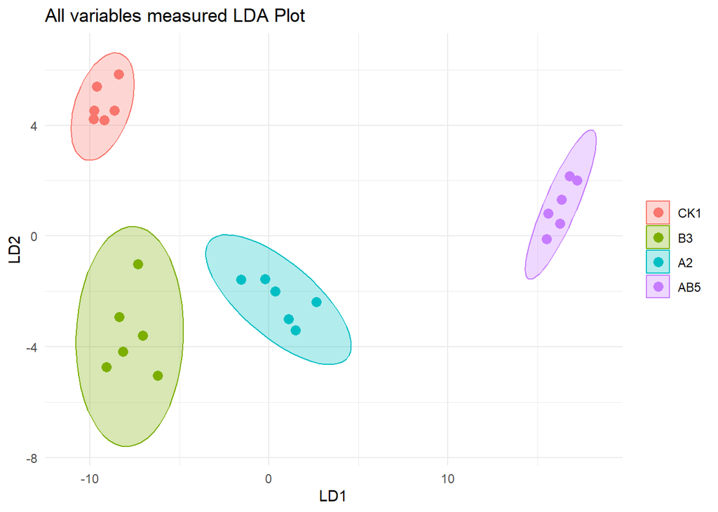

```
##
## Equation for LD1:
##  LD1 = 10.259*Aboveground_Biomass + -1.293*Belowground_Biomass + 9.792*Total_Biomass + -4.946*RootLength + 5.214*RootSurfaceArea + 17.671*RootAverageDiameter + -10.739*Rvolume + 1.006*Rootbranches + -2.693*SIZE + 4.806*`R/S_ratio` + -0.18*HEIGHT + 1.905*`NH4+-N` + -0.859*`NO3-N` + -1.261*Total_N …
##
## Equation for LD2:
##  LD2 = 1.42*Aboveground_Biomass + 2.567*Belowground_Biomass + 3.27*Total_Biomass + 4.471*RootLength + -1.819*RootSurfaceArea + 7.466*RootAverageDiameter + 0.656*Rvolume + -1.146*Rootbranches + -2.7*SIZE + -2.233*`R/S_ratio` + 1.993*HEIGHT + 0.369*`NH4+-N` + 0.634*`NO3-N` + -1.173*Total_N + 0.512*…
```

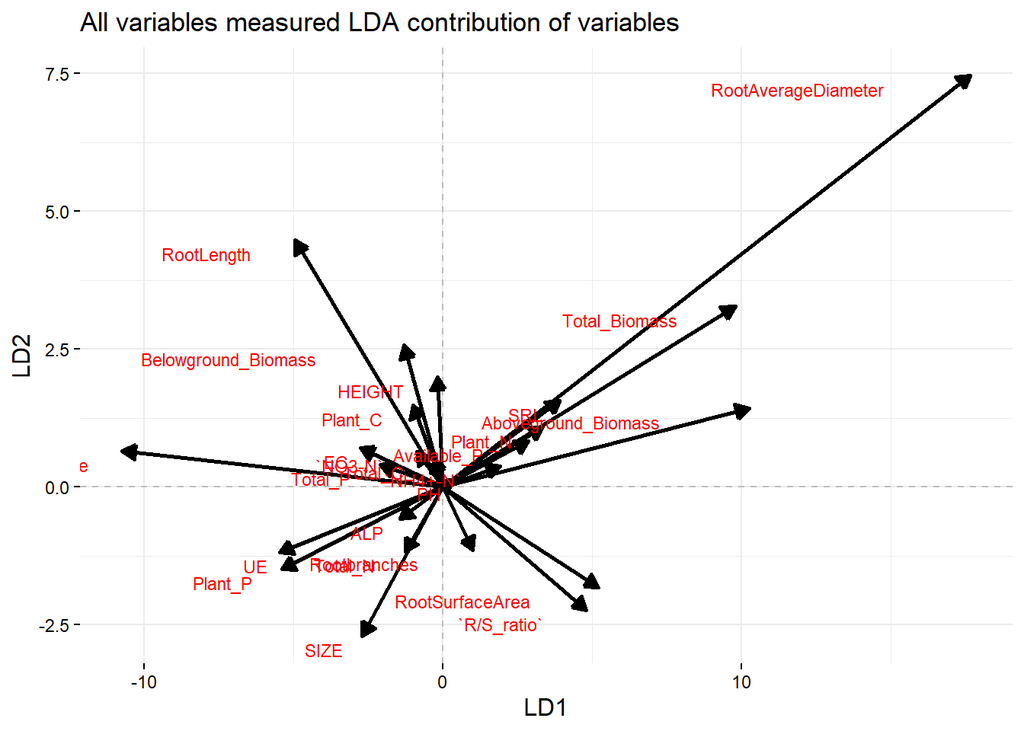

```r
perform_lda <- function(data, group_col, threshold = 0.1, plot_title_prefix = "") {
  # Standardize the data
  data_std <- data
  predictors <- setdiff(names(data), group_col)
  data_std[, predictors] <- scale(data[, predictors])
  data_std[[group_col]] <- as.factor(data_std[[group_col]])

  # Perform LDA
  lda_model <- lda(as.formula(paste(group_col, "~ .")), data = data_std)

  # Extract the LDA equations
  coefficients <- coef(lda_model)
  ld1_equation <- paste(
    "LD1 =",
    paste0(
      round(coefficients[, 1], 3),
      "*", rownames(coefficients),
      collapse = " + "
    )
  )
  ld2_equation <- paste(
    "LD2 =",
    paste0(
      round(coefficients[, 2], 3),
      "*", rownames(coefficients),
      collapse = " + "
    )
  )

  # Predictions and LDA scores
  predictions <- predict(lda_model)
  data_std$LD1 <- predictions$x[, 1]
  data_std$LD2 <- predictions$x[, 2]

  # Plot LDA results
  lda_plot <- ggplot(data_std, aes(x = LD1, y = LD2, color = !!sym(group_col), fill = !!sym(group_col))) +
    geom_point(size = 3) +
    stat_ellipse(geom = "polygon", alpha = 0.3) +
    labs(title = paste(plot_title_prefix, "LDA Plot"), x = "LD1", y = "LD2") +
    theme_minimal() +
    theme(legend.title = element_blank())

  print(lda_plot)  # Print the LDA plot

  # Print the equations below the plot
  cat("\nEquation for LD1:\n", ld1_equation, "\n\n")
  cat("Equation for LD2:\n", ld2_equation, "\n\n")

  # Variable importance
  coefficients_df <- data.frame(
    Variable = rownames(coefficients),
    LD1 = coefficients[, 1],
    LD2 = coefficients[, 2],
    Importance = rowSums(abs(coefficients))
  )

  # Filter for arrows
  coefficients_filtered <- subset(coefficients_df, Importance > threshold)

  # Arrow plot
  arrow_plot <- ggplot(coefficients_filtered, aes(x = 0, y = 0)) +
    geom_hline(yintercept = 0, linetype = "dashed", color = "gray") +
    geom_vline(xintercept = 0, linetype = "dashed", color = "gray") +
    geom_segment(aes(xend = LD1, yend = LD2),
                 arrow = arrow(type = "closed", length = unit(0.1, "inches")),
                 linewidth = 1) +
    geom_text(aes(x = LD1, y = LD2, label = Variable), color = "red", size = 3, hjust = 1.5, vjust = 1.5) +
    labs(title = paste(plot_title_prefix, "LDA contribution of variables"), x = "LD1", y = "LD2") +
    theme_minimal() +
    theme(axis.text = element_text(color = "black"),
          axis.title = element_text(size = 12),
          axis.ticks = element_line(color = "black"))

  print(arrow_plot)  # Print arrow plot to the R graphics device

  return(list(lda_model = lda_model, predictions = predictions, lda_plot = lda_plot, arrow_plot = arrow_plot))
}


big_LDA <- perform_lda(plant_soil, "Group", threshold = 0.1, plot_title_prefix = "All variables measured")
```

# Linear Discriminant Analysis of Plant Parameters and Soil Parameters separately

We then decided to conduct LDA with the variable groupings that we used for the PCA analysis. As seen in the PCA of Plant parameters were much better at separating between groups than soil parameters.

We can see that it is easy to separate the treatment groups based on plant parameters, but it is not a very clear separation based on soil parameters. Which means that plant parameters were more noticably different after treatments than soil parameters.

For the soil parameters according to the equation for the LDA plot the most important variable for LD1 were: Total_P, PH, EC, UE. And for LD2 were: EC, PH and Total_N. As the groupings are not as clear here, as in the LDA for plant parameters we can not really draw a lot of conclusions from this analysis. However some similar variables appear to be important in the LDA analysis as the PCA. Like Plant_P, soil Urease, and EC. Which means that these variables, are not only highly varied between each measurement as well as they are great at separating groups, so the variation is highly correlated with treatments.

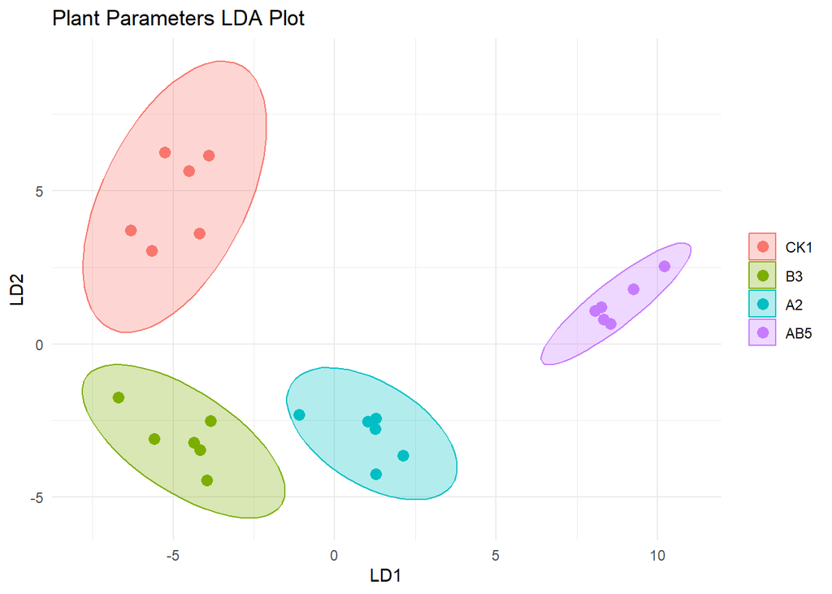

```
##
## Equation for LD1:
##  LD1 = 11.889*Aboveground_Biomass + -10.052*Belowground_Biomass + 5.385*Total_Biomass + 1.547*RootLength + -2.664*RootSurfaceArea + 2.389*RootAverageDiameter + 3.186*Rvolume + -1.346*Rootbranches + 1.079*SIZE + 10.775*`R/S_ratio` + 0.549*HEIGHT + 1.408*Plant_P + 1.909*Plant_N + 0.058*Plant_C + 3.…
##
## Equation for LD2:
##  LD2 = 7.416*Aboveground_Biomass + -5.627*Belowground_Biomass + 3.807*Total_Biomass + 6.165*RootLength + -3.214*RootSurfaceArea + 5.949*RootAverageDiameter + 3.572*Rvolume + -2.406*Rootbranches + -2.418*SIZE + 4.166*`R/S_ratio` + 0.45*HEIGHT + 0.407*Plant_P + 1.132*Plant_N + 1.424*Plant_C + 2.143…
```

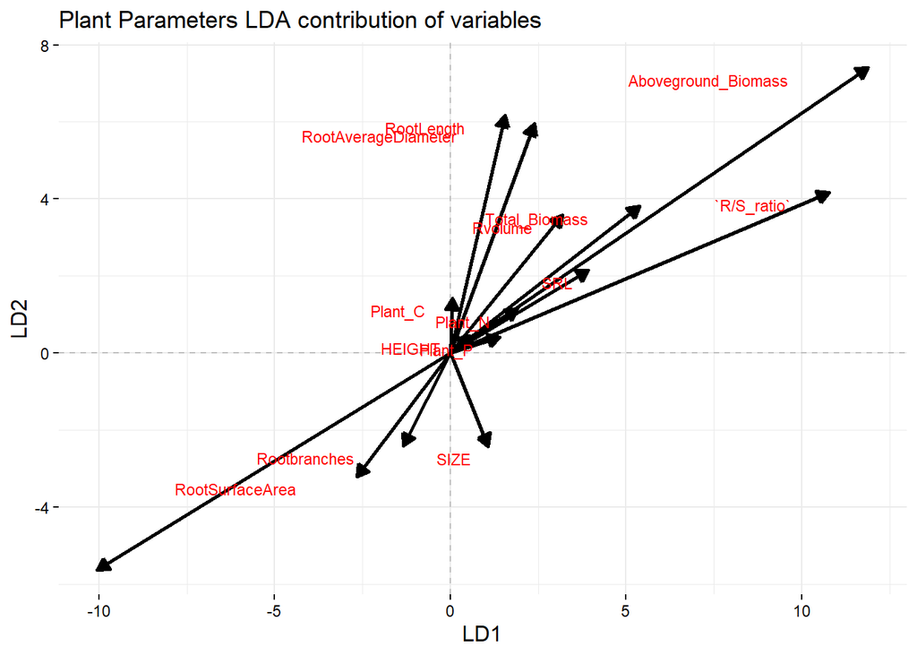

```r
perform_lda <- function(data, group_col, threshold = 0.1, plot_title_prefix = "") {
  # Standardize the data
  data_std <- data
  predictors <- setdiff(names(data), group_col)
  data_std[, predictors] <- scale(data[, predictors])
  data_std[[group_col]] <- as.factor(data_std[[group_col]])

  # Perform LDA
  lda_model <- lda(as.formula(paste(group_col, "~ .")), data = data_std)

  # Extract the LDA equations
  coefficients <- coef(lda_model)
  ld1_equation <- paste(
    "LD1 =",
    paste0(
      round(coefficients[, 1], 3),
      "*", rownames(coefficients),
      collapse = " + "
    )
  )
  ld2_equation <- paste(
    "LD2 =",
    paste0(
      round(coefficients[, 2], 3),
      "*", rownames(coefficients),
      collapse = " + "
    )
  )

  # Predictions and LDA scores
  predictions <- predict(lda_model)
  data_std$LD1 <- predictions$x[, 1]
  data_std$LD2 <- predictions$x[, 2]

  # Plot LDA results
  lda_plot <- ggplot(data_std, aes(x = LD1, y = LD2, color = !!sym(group_col), fill = !!sym(group_col))) +
    geom_point(size = 3) +
    stat_ellipse(geom = "polygon", alpha = 0.3) +
    labs(title = paste(plot_title_prefix, "LDA Plot"), x = "LD1", y = "LD2") +
    theme_minimal() +
    theme(legend.title = element_blank())

  print(lda_plot)  # Print the LDA plot

  # Print the equations below the plot
  cat("\nEquation for LD1:\n", ld1_equation, "\n\n")
  cat("Equation for LD2:\n", ld2_equation, "\n\n")

  # Variable importance
  coefficients_df <- data.frame(
    Variable = rownames(coefficients),
    LD1 = coefficients[, 1],
    LD2 = coefficients[, 2],
    Importance = rowSums(abs(coefficients))
  )

  # Filter for arrows
  coefficients_filtered <- subset(coefficients_df, Importance > threshold)

  # Arrow plot
  arrow_plot <- ggplot(coefficients_filtered, aes(x = 0, y = 0)) +
    geom_hline(yintercept = 0, linetype = "dashed", color = "gray") +
    geom_vline(xintercept = 0, linetype = "dashed", color = "gray") +
    geom_segment(aes(xend = LD1, yend = LD2),
                 arrow = arrow(type = "closed", length = unit(0.1, "inches")),
                 linewidth = 1) +
    geom_text(aes(x = LD1, y = LD2, label = Variable), color = "red", size = 3, hjust = 1.5, vjust = 1.5) +
    labs(title = paste(plot_title_prefix, "LDA contribution of variables"), x = "LD1", y = "LD2") +
    theme_minimal() +
    theme(axis.text = element_text(color = "black"),
          axis.title = element_text(size = 12),
          axis.ticks = element_line(color = "black"))

  print(arrow_plot)  # Print arrow plot to the R graphics device

  return(list(lda_model = lda_model, predictions = predictions, lda_plot = lda_plot, arrow_plot = arrow_plot))
}


# Perform LDA for Plant Parameters
plant_lda_results <- perform_lda(Plant_param, "Group", threshold = 0.1, plot_title_prefix = "Plant Parameters")
```

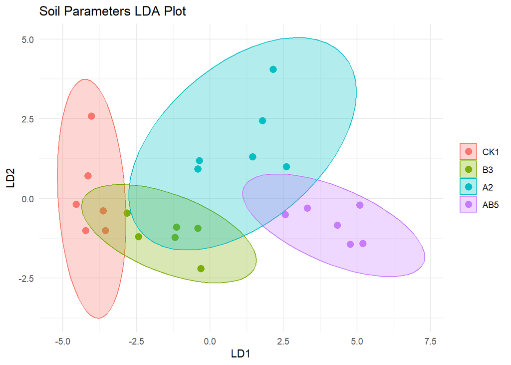

```
##
## Equation for LD1:
##  LD1 = 0.713*`NH4+-N` + -0.7*`NO3-N` + -0.147*Total_N + -0.991*Total_C + -0.029*Available_P + -1.504*Total_P + 0.703*ALP + 1.266*UE + -2.854*EC + -1.134*PH
##
## Equation for LD2:
##  LD2 = -0.226*`NH4+-N` + -0.477*`NO3-N` + 1.109*Total_N + -0.147*Total_C + 0.106*Available_P + -0.495*Total_P + -0.018*ALP + 0.981*UE + 1.835*EC + 1.523*PH
```

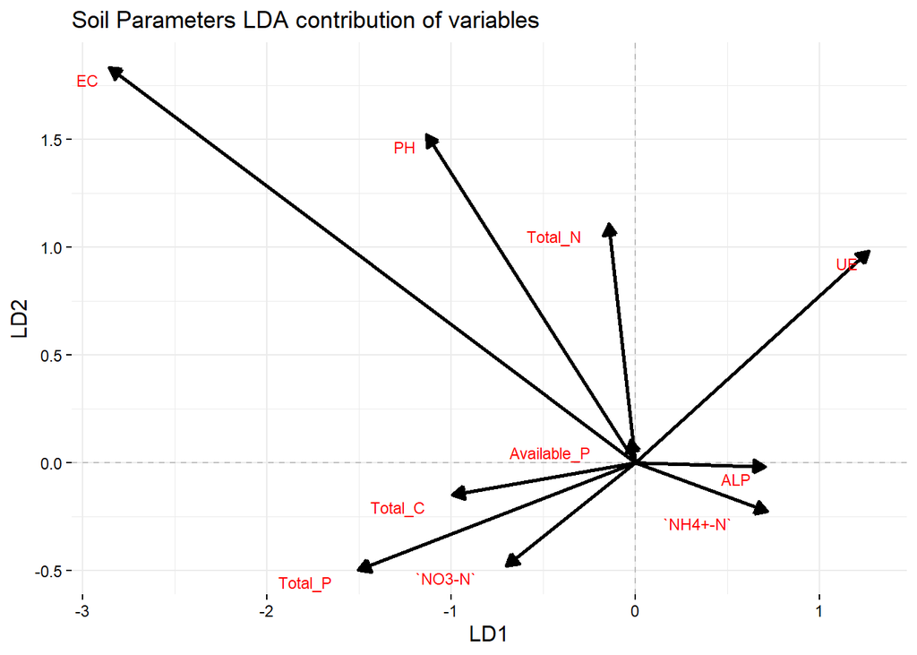

```r
# Perform LDA for Soil Parameters
soil_lda_results <- perform_lda(Soil_param, "Group", threshold = 0.1, plot_title_prefix = "Soil Parameters")
```

# Correlogram of all variables

We thought it would be a good idea to showcase the correlations between all variables in a correlogram. In this format it is easy to see that some variables share some correlation if we don’t consider groups as well. We then took the strongest correlations and some of the interesting ones and plotted them as linerar regressions below.

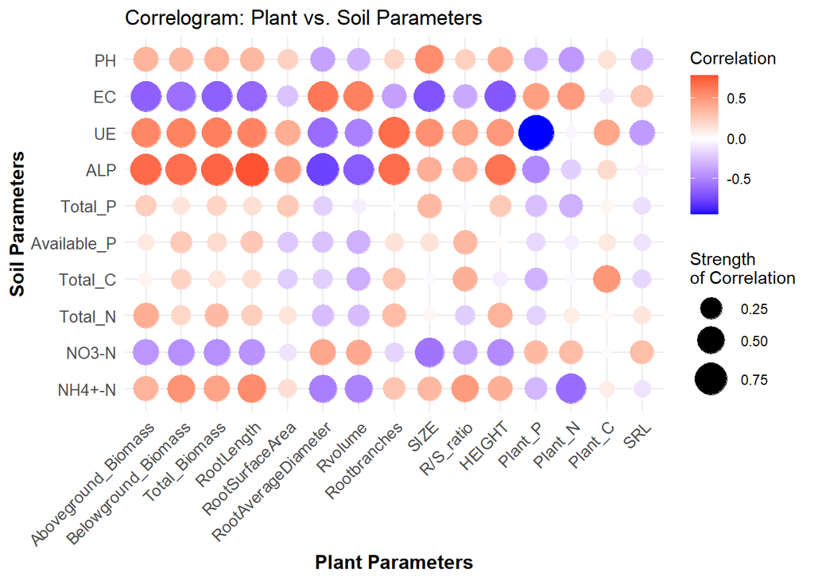

```r
# Load necessary libraries
if (!require(ggplot2)) install.packages("ggplot2")
library(ggplot2)

# Example: Assuming Plant_param and Soil_param data are already loaded
# Calculate correlation matrix
correlation_matrix <- cor(Plant_param[, -1], Soil_param[, -1], use = "pairwise.complete.obs")

# Convert the correlation matrix to a long format
correlation_data <- as.data.frame(as.table(correlation_matrix))
colnames(correlation_data) <- c("Plant_Parameter", "Soil_Parameter", "Correlation")

# Create the correlogram plot with circles
correlogram <- ggplot(correlation_data, aes(x = Plant_Parameter, y = Soil_Parameter)) +
  geom_point(aes(size = abs(Correlation), color = Correlation)) +
  scale_color_gradient2(low = "blue", mid = "white", high = "red", midpoint = 0,
                        name = "Correlation") +
  scale_size_continuous(range = c(2, 10), name = "Strength\nof Correlation") +
  theme_minimal() +
  theme(axis.text.x = element_text(angle = 45, hjust = 1, vjust = 1),
        axis.text = element_text(size = 10),
        axis.title = element_text(size = 12, face = "bold")) +
  labs(title = "Correlogram: Plant vs. Soil Parameters",
       x = "Plant Parameters",
       y = "Soil Parameters")
print(correlogram)
```

# Correlogramms showing the correlation Specific Root Length (SRL) has with plant and soil parameters separately

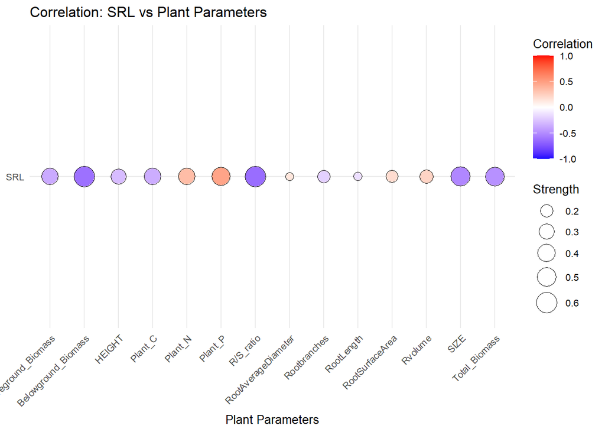

```r
# Load required libraries

if (!require(ggplot2)) install.packages("ggplot2")
if (!require(reshape2)) install.packages("reshape2")
library(ggplot2)
library(reshape2)

# Extract SRL (Specific Root Length)
SRL <- Plant_param$SRL

# Exclude SRL column and retain only numeric columns from Plant parameters
Plant_param_no_srl <- Plant_param[, !names(Plant_param) %in% "SRL"]
Plant_param_no_srl <- Plant_param_no_srl[sapply(Plant_param_no_srl, is.numeric)]  # Retain only numeric columns

# Exclude SRL column and retain only numeric columns from Soil parameters
Soil_param_numeric <- Soil_param[sapply(Soil_param, is.numeric)]  # Retain only numeric columns

# Prepare data for correlogram: SRL vs Plant parameters
plant_corr <- sapply(Plant_param_no_srl, function(x) cor(SRL, x, use = "complete.obs"))
plant_corr_df <- data.frame(Variable = names(plant_corr), Correlation = plant_corr)
plant_corr_df <- plant_corr_df[order(plant_corr_df$Correlation, decreasing = TRUE), ]

# Prepare data for correlogram: SRL vs Soil parameters
soil_corr <- sapply(Soil_param_numeric, function(x) cor(SRL, x, use = "complete.obs"))
soil_corr_df <- data.frame(Variable = names(soil_corr), Correlation = soil_corr)
soil_corr_df <- soil_corr_df[order(soil_corr_df$Correlation, decreasing = TRUE), ]

# Plot 1: SRL vs Plant parameters
plot1 <- ggplot(plant_corr_df, aes(x = Variable, y = "SRL", fill = Correlation, size = abs(Correlation))) +
  geom_point(shape = 21, color = "black") +
  scale_fill_gradient2(low = "blue", mid = "white", high = "red", midpoint = 0, limits = c(-1, 1)) +
  scale_size_continuous(range = c(3, 8)) +
  labs(title = "Correlation: SRL vs Plant Parameters",
       x = "Plant Parameters", y = NULL, fill = "Correlation", size = "Strength") +
  theme_minimal(base_size = 10) +
  theme(
    axis.text.x = element_text(angle = 45, hjust = 1, vjust = 1),
    axis.title.x = element_text(size = 10, margin = margin(t = 5)),
    plot.margin = margin(5, 5, 5, 5)
  )
print(plot1)
```

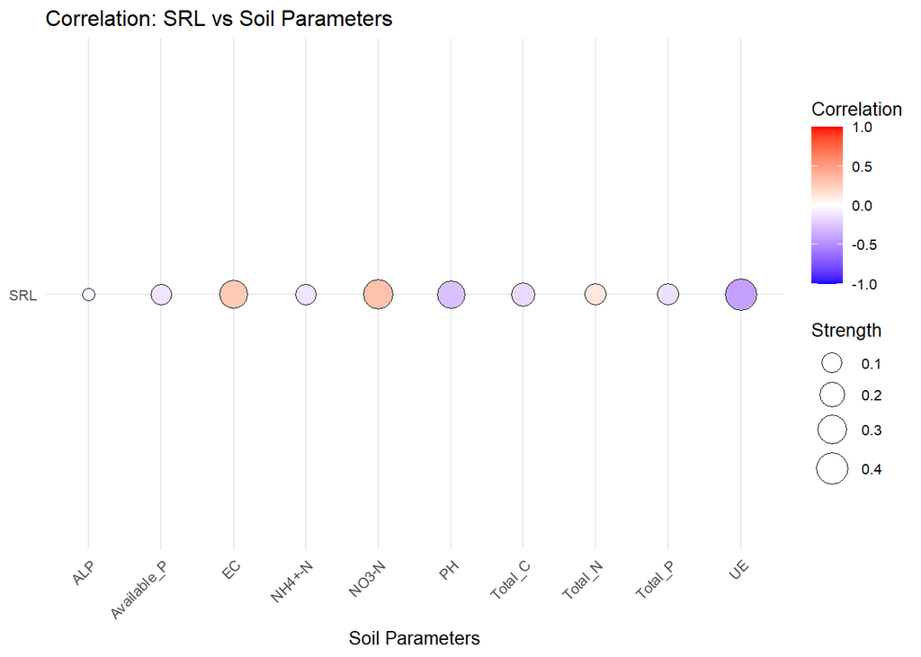

```r
# Plot 2: SRL vs Soil parameters
plot2 <- ggplot(soil_corr_df, aes(x = Variable, y = "SRL", fill = Correlation, size = abs(Correlation))) +
  geom_point(shape = 21, color = "black") +
  scale_fill_gradient2(low = "blue", mid = "white", high = "red", midpoint = 0, limits = c(-1, 1)) +
  scale_size_continuous(range = c(3, 8)) +
  labs(title = "Correlation: SRL vs Soil Parameters",
       x = "Soil Parameters", y = NULL, fill = "Correlation", size = "Strength") +
  theme_minimal(base_size = 10) +
  theme(
    axis.text.x = element_text(angle = 45, hjust = 1, vjust = 1),
    axis.title.x = element_text(size = 10, margin = margin(t = 5)),
    plot.margin = margin(5, 5, 5, 5)
  )
print(plot2)
```

# Some notable correlations

We thougt it would be important to show these correlations on graphs as well. They are not strong however they could be considered for further analysis and study, as the study of the original paper doesn’t have a high sample number these correlations could be strengthened or dismissed with a study containing more samples.

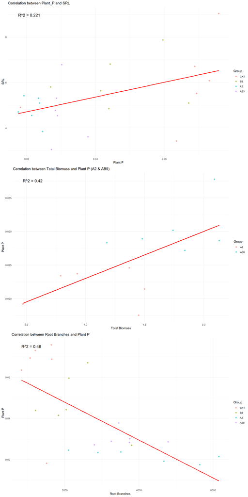

```r
# Load required libraries
library(ggplot2)
library(gridExtra)

# Third plot: Correlation between Plant_P and SRL
subset_data <- plant_soil[, c("Plant_P", "SRL", "Group")]
model <- lm(SRL ~ Plant_P, data = subset_data)
r_squared <- summary(model)$r.squared

p3 <- ggplot(subset_data, aes(x = Plant_P, y = SRL, color = Group)) +
  geom_point(alpha = 0.6, size = 2) +
  geom_smooth(method = "lm", color = "red", se = FALSE) +
  annotate("text", x = min(subset_data$Plant_P, na.rm = TRUE),
           y = max(subset_data$SRL, na.rm = TRUE),
           label = paste("R^2 =", round(r_squared, 3)),
           hjust = 0, vjust = 1, size = 5, color = "black") +
  labs(title = "Correlation between Plant_P and SRL",
       x = "Plant P", y = "SRL") +
  theme_minimal()

# Sixth plot: Correlation between Total Biomass and Plant P (for Group A2 & AB5)
subset_data <- plant_soil[plant_soil$Group %in% c("A2", "AB5"), c("Total_Biomass", "Plant_P", "Group")]
model <- lm(Plant_P ~ Total_Biomass, data = subset_data)
r_squared <- summary(model)$r.squared

p6 <- ggplot(subset_data, aes(x = Total_Biomass, y = Plant_P, color = Group)) +
  geom_point(alpha = 0.6, size = 2) +
  geom_smooth(method = "lm", color = "red", se = FALSE) +
  annotate("text", x = min(subset_data$Total_Biomass, na.rm = TRUE),
           y = max(subset_data$Plant_P, na.rm = TRUE),
           label = paste("R^2 =", round(r_squared, 3)),
           hjust = 0, vjust = 1, size = 5, color = "black") +
  labs(title = "Correlation between Total Biomass and Plant P (A2 & AB5)",
       x = "Total Biomass", y = "Plant P") +
  theme_minimal()

# Eighth plot: Correlation between Root Branches and Plant P
subset_data <- plant_soil[, c("Rootbranches", "Plant_P", "Group")]
model <- lm(Plant_P ~ Rootbranches, data = subset_data)
r_squared <- summary(model)$r.squared

p8 <- ggplot(subset_data, aes(x = Rootbranches, y = Plant_P, color = Group)) +
  geom_point(alpha = 0.6, size = 2) +
  geom_smooth(method = "lm", color = "red", se = FALSE) +
  annotate("text", x = min(subset_data$Rootbranches, na.rm = TRUE),
           y = max(subset_data$Plant_P, na.rm = TRUE),
           label = paste("R^2 =", round(r_squared, 3)),
           hjust = 0, vjust = 1, size = 5, color = "black") +
  labs(title = "Correlation between Root Branches and Plant P",
       x = "Root Branches", y = "Plant P") +
  theme_minimal()

# Arrange plots 3, 6, and 8 in a single column
grid.arrange(p3, p6, p8, ncol = 1)
```

# Urease and Plant Phosphorus non-linear relation

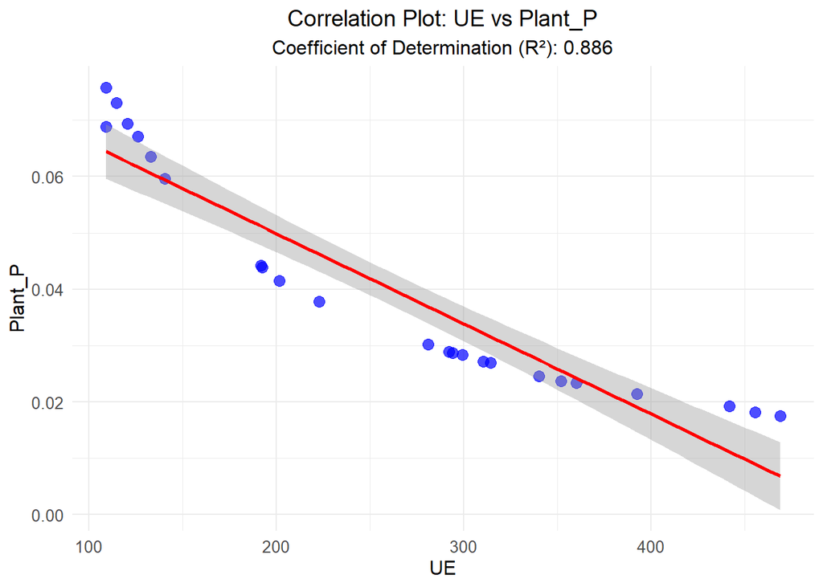

```r
 # Calculate the correlation coefficient
correlation <- cor(plant_soil$UE, plant_soil$Plant_P, use = "complete.obs")

# Calculate R-squared
r_squared <- correlation^2

# Create the correlation plot
correlation_plot <- ggplot(plant_soil, aes(x = UE, y = Plant_P)) +
  geom_point(color = "blue", size = 3, alpha = 0.7) +
  geom_smooth(method = "lm", color = "red", se = TRUE) +  # Add regression line
  labs(title = "Correlation Plot: UE vs Plant_P",
       subtitle = paste("Coefficient of Determination (R²):", round(r_squared, 3)),
       x = "UE",
       y = "Plant_P") +
  theme_minimal() +
  theme(plot.title = element_text(hjust = 0.5, size = 14),
        plot.subtitle = element_text(hjust = 0.5, size = 12),
        axis.title = element_text(size = 12),
        axis.text = element_text(size = 10))

# Print the plot
print(correlation_plot)
```

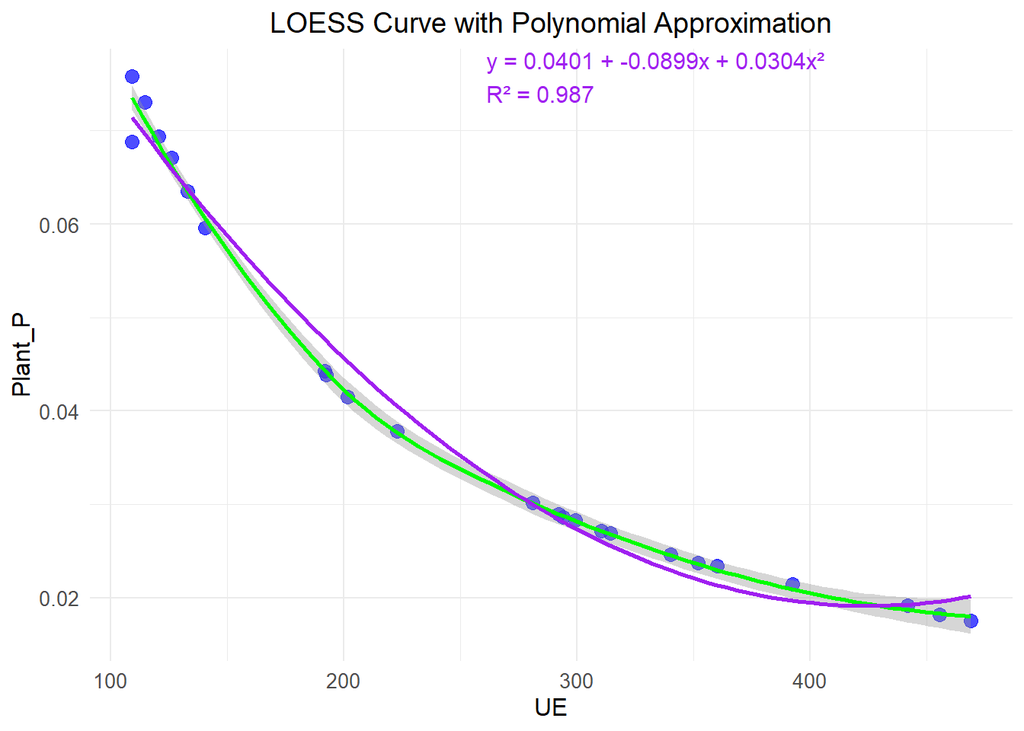

```r
# Fit a polynomial regression model
poly_model <- lm(Plant_P ~ poly(UE, 2), data = plant_soil)

# Extract coefficients and create equation text
coefs <- coef(poly_model)
equation <- paste0("y = ", signif(coefs[1], 3),
                   " + ", signif(coefs[2], 3), "x",
                   " + ", signif(coefs[3], 3), "x²")

# Calculate R-squared
r_squared <- signif(summary(poly_model)$r.squared, 3)

# Combine equation and R-squared
equation_with_r2 <- paste0(equation, "\nR² = ", r_squared)

# Plot with LOESS and polynomial equation
ggplot(plant_soil, aes(x = UE, y = Plant_P)) +
  geom_point(color = "blue", size = 3, alpha = 0.7) +
  geom_smooth(method = "loess", color = "green", se = TRUE) +
  stat_smooth(method = "lm", formula = y ~ poly(x, 2), color = "purple", se = FALSE) +
  annotate("text", x = mean(plant_soil$UE), y = max(plant_soil$Plant_P, na.rm = TRUE),
           label = equation_with_r2, color = "purple", size = 4, hjust = 0) +
  labs(title = "LOESS Curve with Polynomial Approximation",
       x = "UE",
       y = "Plant_P") +
  theme_minimal() +
  theme(plot.title = element_text(hjust = 0.5, size = 14),
        axis.title = element_text(size = 12),
        axis.text = element_text(size = 10))
```

## 7. Discussion.

The PCA analysis revealed that plant parameters are much better at separating treatment groups than soil parameters. Plant PC1 explained 73.2% of the variance, with key contributors being traits like biomass and root length. This shows that treatments had a strong impact on plant traits, making them more responsive indicators of treatment effects. Soil PC1, explaining 42.9% of the variance, was less effective at differentiating groups, as soil parameters showed slight variations across treatments.